# homework_2_Lee_Jared

## Section 3.6.1: #1-5. Extra Credit: Do #6

### 1) What geom would you use to draw a line chart? A boxplot? A histogram? An area chart?

Line chart: geom_line() Boxplot: geom_boxplot() Histogram: geom_histogram() Area Chart: geom_area()

### 2)Run this code in your head and predict what the output will look like. Then, run the code in R and check your predictions.

Prediction: Two different geommetrical funtions are used. The x and y axises are defined in ggplot() and apply to both. Color that adds a 3rd variable is also added here so both geom funtions should be color coded by drv.

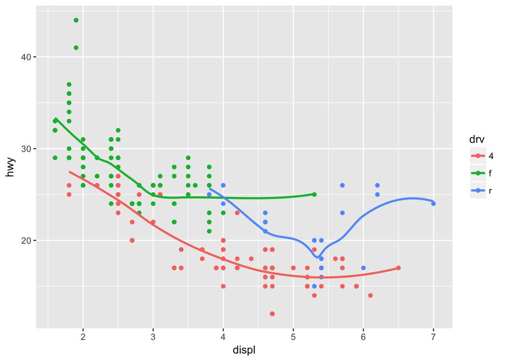

```r
ggplot(data = mpg, mapping = aes(x = displ, y = hwy, color = drv)) +
  geom_point() +
  geom_smooth(se = FALSE)
```

Prediction check: se = FALSE controls whether the grey bands are displayed which show the variation.

### 3)What does show.legend = FALSE do? What happens if you remove it? Why do you think I used it earlier in the chapter?

show.legend = FALSE removes the legend from the graph. If you remove that line, the legend appears which is the default. I’m guessing it was used earlier in the chapter to create a simpler illustration of how geom_smooth() works.

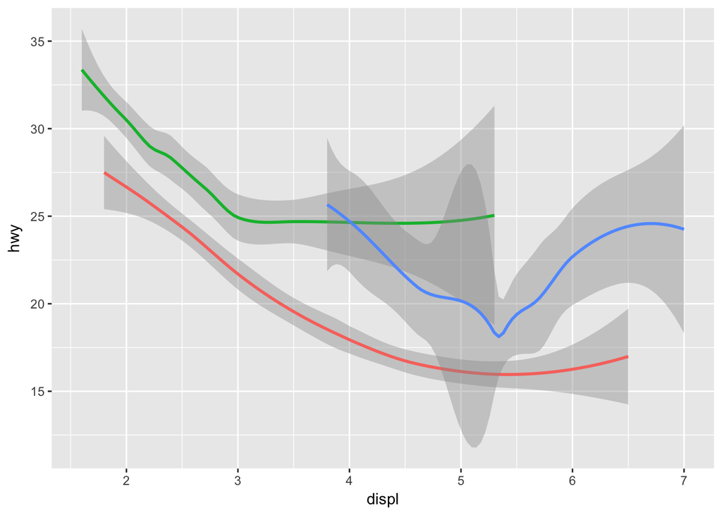

```r
ggplot(data = mpg) +
  geom_smooth(mapping = aes(x = displ, y = hwy, color = drv), show.legend = FALSE)
```

### 4 What does the se argument to geom_smooth() do?

The se argument displays grey area to show the distribution of the observations.

### 5) Will these two graphs look different? Why/why not?

The two graphs look the same. The x and y axises are just defined differently. The first one sets x and y globally. The second sets x and y for each geometric funtion, but they are mapped the same.

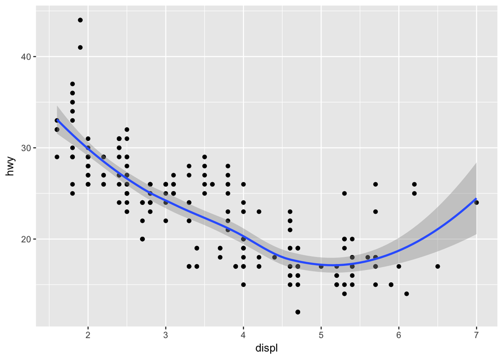

```r
ggplot(data = mpg, mapping = aes(x = displ, y = hwy)) +
  geom_point() +
  geom_smooth()
```

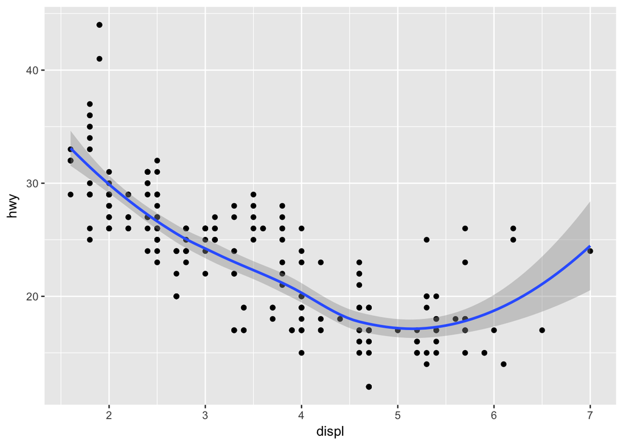

```r
ggplot() +
  geom_point(data = mpg, mapping = aes(x = displ, y = hwy)) +
  geom_smooth(data = mpg, mapping = aes(x = displ, y = hwy))
```

### 6)

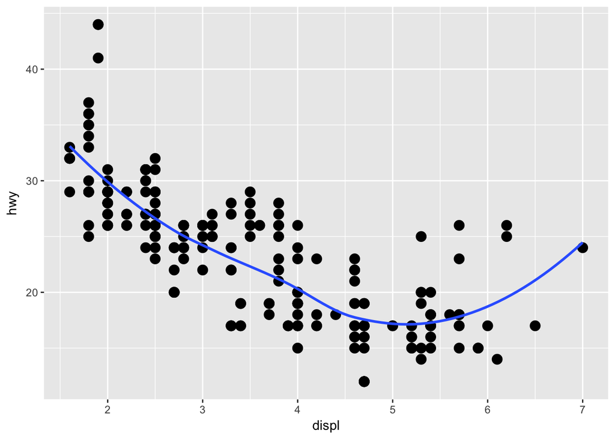

```r
ggplot(mpg, aes(x = displ, y = hwy)) +
  geom_point(stroke = 2) +
  geom_smooth(se = FALSE)
```

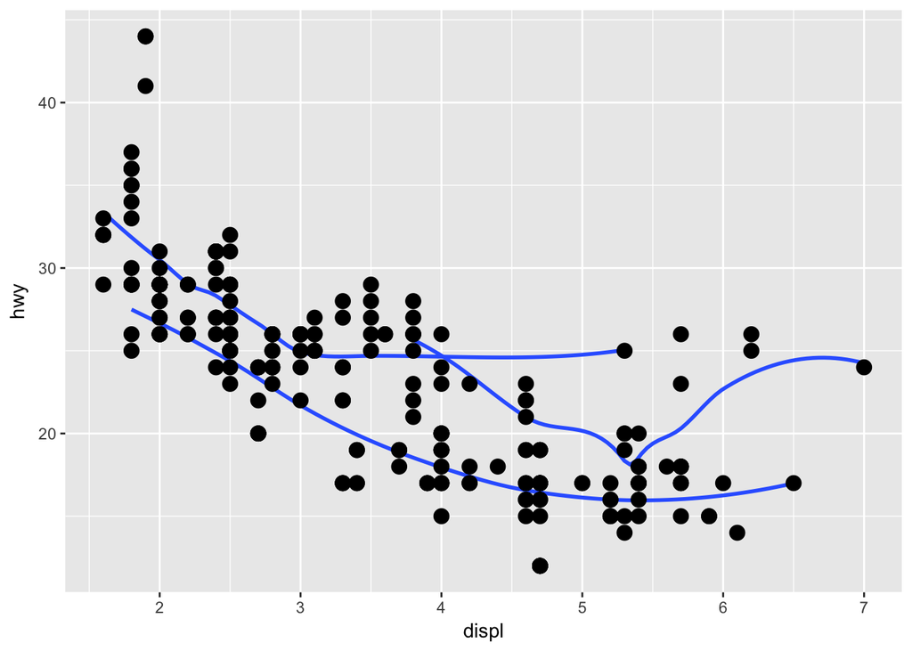

```r
ggplot(mpg, aes(x = displ, y = hwy)) +
  geom_smooth(aes(group = drv), se = FALSE) +
  geom_point(stroke = 2)
```

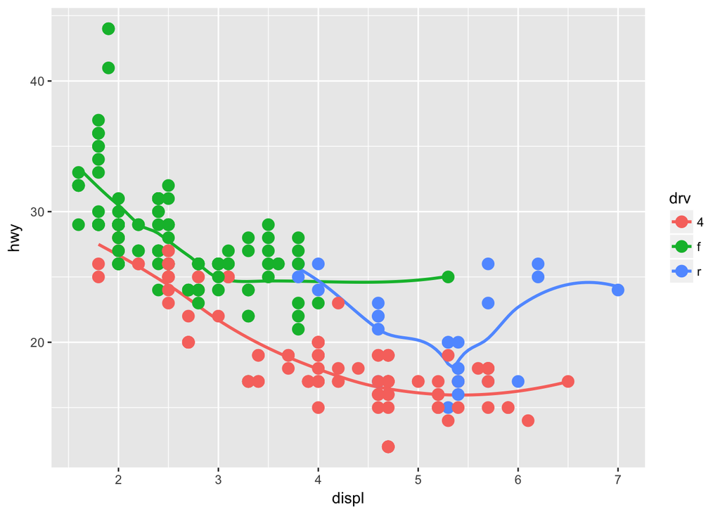

```r
ggplot(mpg, aes(x = displ, y = hwy, color = drv)) +
  geom_smooth(se = FALSE) +
  geom_point(stroke = 2)
```

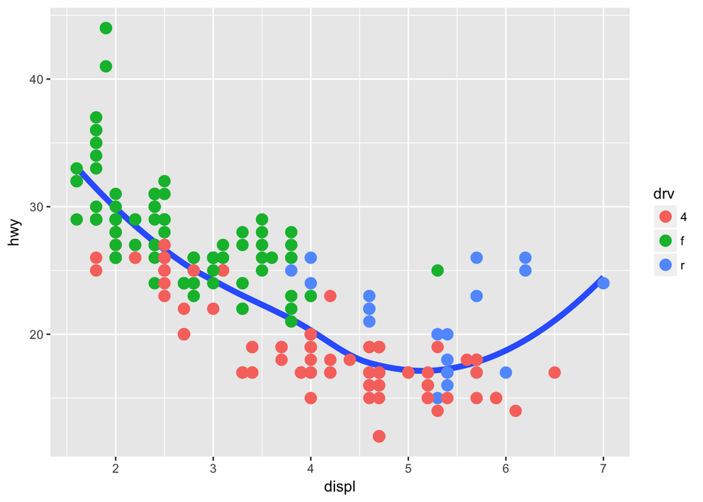

```r
ggplot(mpg, aes(x = displ, y = hwy)) +
  geom_smooth(se = FALSE, size = 2) +
  geom_point(aes(color = drv), stroke = 2)
```

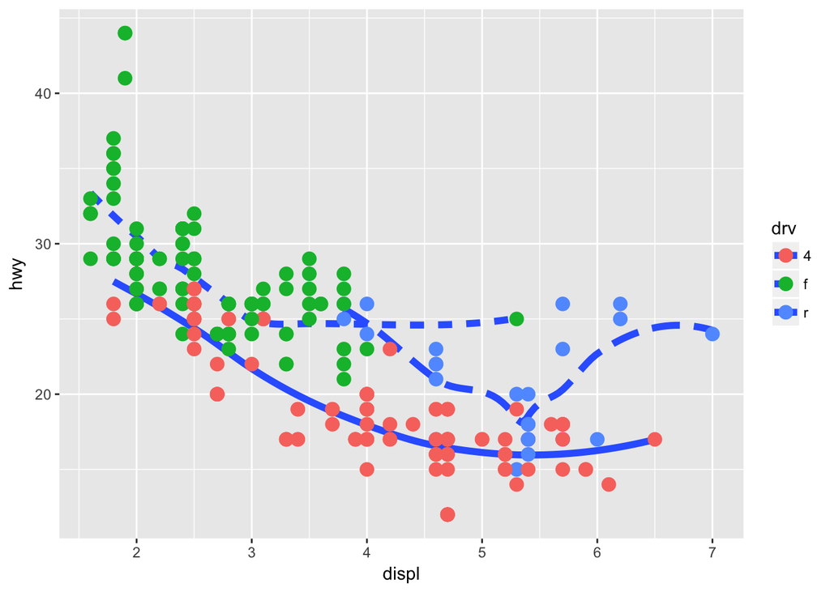

```r
ggplot(mpg, aes(x = displ, y = hwy)) +
  geom_smooth(aes(linetype = drv), se = FALSE, size = 2) +
  geom_point(aes(color = drv), stroke = 2)
```

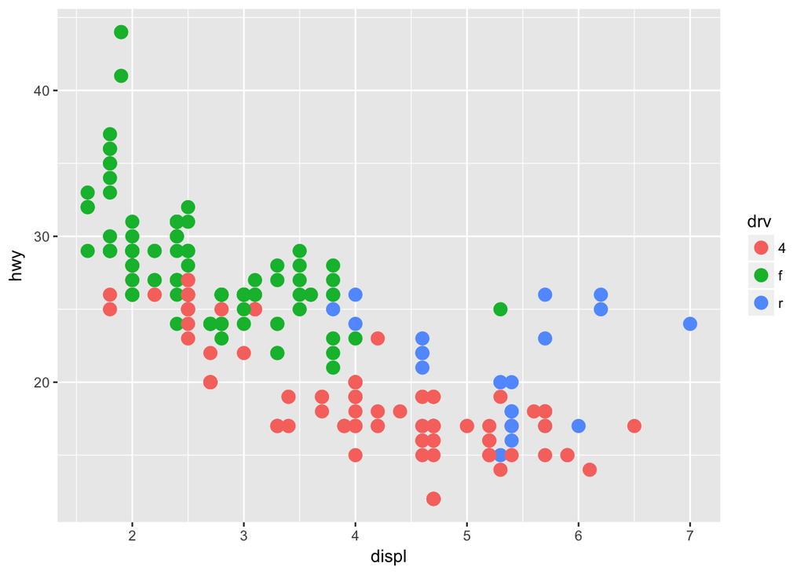

```r
ggplot(mpg, aes(x = displ, y = hwy)) +
  geom_point(aes(color = drv), stroke = 2, fill = 3)
```

## Section 3.7.1: #2 only

### 2) What does geom_col() do? How is it different to geom_bar()?

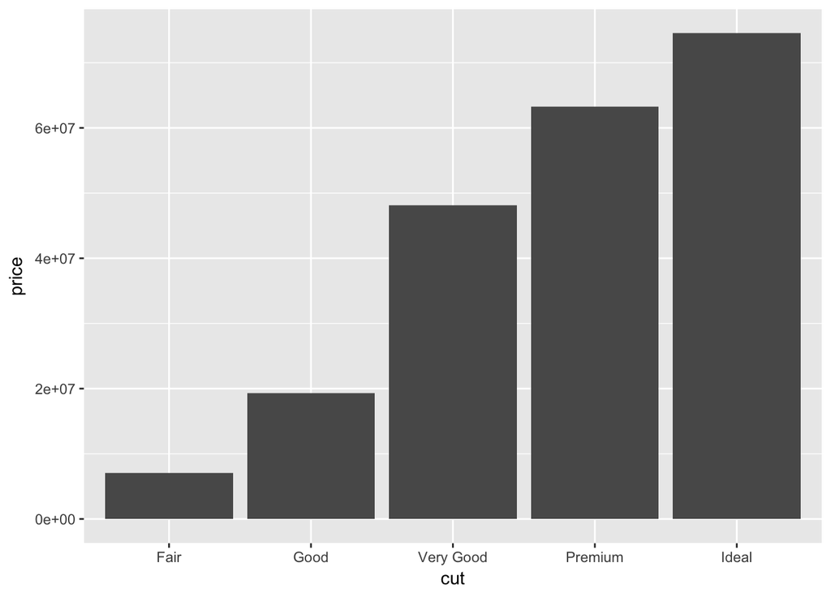

```r
ggplot(diamonds) +
  geom_col(aes(x = cut, y = price))
```

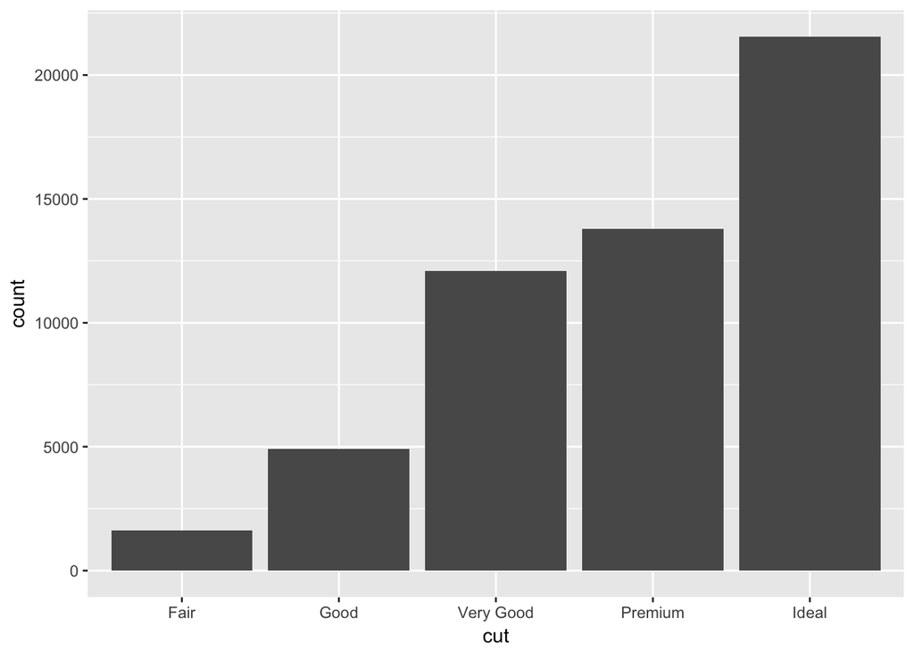

```r
ggplot(diamonds) +
  geom_bar(aes(x = cut))
```

## Extra Credit: Look at the data graphics at the following link: What is a Data Scientist. Please briefly critique the designer’s choices. What works? What doesn’t work? What would you have done differently?

#### What works:

- The heading for each section states the key finding from the visualizations below them.
- The graphs/charts are reasonably simplistic and don’t show overwhelming amounts of data.

#### What doesn’t work:

- Donut chart is difficult to compare pieces/slices to each other. Small sections aren’t represented clearly.
- The area blocks are difficult to distingush. The values are so close to eachother, it doesn’t make sense to visualize them this way when they’re so similar.
- The bar charts show far too many charts. Grouping the data into 1 or 2 charts/graphs would be easier to read and compare than 10 invidual charts.

#### Do differently:

- All visualizations are a shade of blue. Another color to highlight key insights would be extremely helpful.
- The top of the infographic doesn’t define the problem well. It’s not summarized at the top what the study is about. Having just a paragraph is too verbose.
- The end could use a summary of the key learnings.